# BiciMad and Heatmaps

Pablo

2017-09-13

> In this post we will analyze Madrid’s electric bike hire service, BiciMAD (in London Santander Cycles, in Paris Vélib, etc…). We will create calendar heatmaps and a growth chart using the publicly available data.

# Libraries

We first install and load the libraries.

```r
library(ggplot2) # For amazing charts
library(tidyverse) # Data wrangling
library(hrbrthemes) # Aesthetic defaults for ggplot2 charts
library(readr) # Reading data from csv
library(formattable) # Friendy data frame can be rendered as HTML table
library(lubridate) # Makes it easier to work with dates and times
```

# Importing data

The data can be obtained from datosabiertos - the free and open data-sharing portal where anyone can access data relating to the Madrid [^1].

Steps to follow:

- Download “Usos acumulados por dia de abono anual y ocasional” excel table
- Then export to csv
- Remove “Usos julio 2017-Table 1” (we are not interested in this data)
- Rename the remaining file to BiciMAD

```r
bicimad_rides <- read_csv("BiciMAD.csv")
```

# Cleaning/Transforming

Once we have all the rides loaded we can start cleansing the data and making the variables we are interested in:

- Transforming date column from character/string to date
- Adding two columns: weekday and year
- Removing year 2014 (activity sirges in 2015, when people know about it)

```r
# select columns interested and renamed them
bicimad_rides <- bicimad_rides %>% select(DIA,`Usos bicis total`,`Usos total acumulado desde inicio`) %>% rename(date = DIA, daily_rides = `Usos bicis total`, accumulated = `Usos total acumulado desde inicio`)

# Transform variable, create new columns and skip year 2014
bicimad_rides <- bicimad_rides %>%
  mutate(date = mdy(date)) %>%
  mutate(month = month(date, label = TRUE, abbr = TRUE)) %>%
  mutate(weekday = wday(date, label=TRUE, abbr=TRUE)) %>%
  mutate(year = year(date)) %>%
  mutate(week=as.numeric(format(date,"%W"))) # Week 00-53 with Monday as first day of the week

bicimad_rides <- bicimad_rides %>% filter(year != "2014")

# Aggregate data with summarise
bicimad_rides <- bicimad_rides %>% group_by(date,year, month, week, weekday) %>% summarise(numtrips=sum(daily_rides), accumulated=sum(accumulated))
View(bicimad_rides)
```

# Plot

### Heatmap

Now we will use the handy dplyr::summarise to get our aggregated data for each day. Then we can plot.

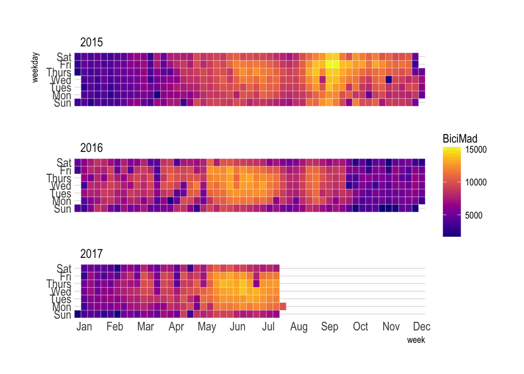

```r
ggplot(bicimad_rides, aes(x = week, y = weekday, fill = numtrips)) +
    viridis::scale_fill_viridis(name="BiciMad",
                       option = 'C',
                       direction = 1,
                       na.value = "grey93") +
    geom_tile(color = 'white', size = 0.1) +
    facet_wrap('year', ncol = 1) +
    scale_x_continuous(
      expand = c(0, 0),
      breaks = seq(1, 52, length = 12),
      labels = c("Jan", "Feb", "Mar", "Apr", "May", "Jun",
                 "Jul", "Aug", "Sep", "Oct", "Nov", "Dec")) +
   theme_ipsum(grid="Y")
```

### Growth

Now, how has BiciMAD grown over the past years?

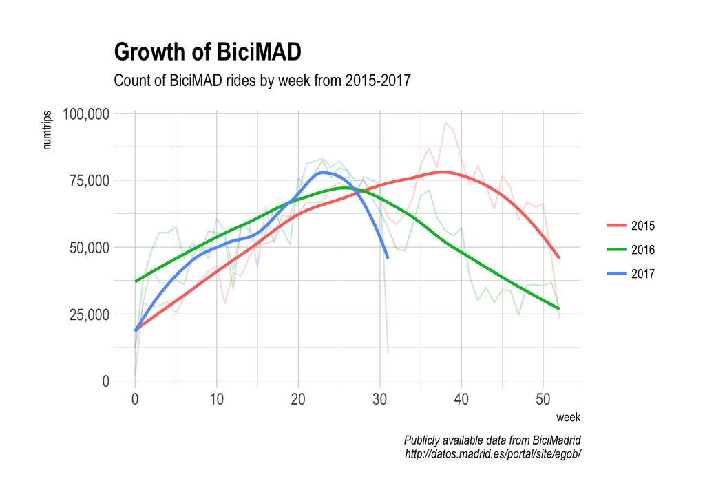

```r
weekly.rides <- bicimad_rides %>% group_by(year, week) %>% summarise(numtrips=sum(numtrips))
View(weekly.rides)

ggplot(weekly.rides,aes(x=week,y=numtrips,color=factor(year))) +
  geom_line(alpha=.25) +
  geom_smooth(se=F,method='loess',alpha=.35) +
  theme_ipsum() +
  labs(
    title='Growth of BiciMAD',
    subtitle='Count of BiciMAD rides by week from 2015-2017',
    caption='Publicly available data from BiciMadrid\nhttp://datos.madrid.es/portal/site/egob/') +
  theme(legend.title=element_blank()) +
  scale_y_continuous(labels=scales::comma)
```

```r
bicimad_rides_year <- bicimad_rides %>% group_by(year) %>% summarise(numtrips=sum(numtrips))
bicimad_rides_year
```

```
## # A tibble: 3 x 2
##    year numtrips
##   <dbl>    <dbl>
## 1  2015  3075454
## 2  2016  2807137
## 3  2017  1779077
```

```r
year.rides <- data.frame( year = c(2015, 2016, 2017),
                          accumulated = accounting(c(3075454, 2807137, 1779077), format = "d"))
formattable(year.rides)
```

| year | accumulated |
| --- | --- |
| 2015 | 3,075,454 |
| 2016 | 2,807,137 |
| 2017 | 1,779,077 |

According to the figures, it looks like the user base has somewhat remained stagnant. Rise counts was probably highest in 2015. 2017 though seems to have slumped a bit specially in July ths year. Reasons? Other large bike-share services, roads not accomadated yet for cyclists, defectuos bykes and docking stations, etc…

Thats it. We now have the heat map and the growth chart!

[^1]: [datosabiertos: used bitly to shorten the link] (http://bit.ly/2azyZ2O)